# Mini-Assignment 4

Uijeong “UJ” Hwang

2026-10-08

Mini assignments are designed to give you an opportunity to practice and better understand the class material through hands-on activities. **Do not share your work with other students – not your RPubs username, not a document URL, not the HTML file – as this could lead to academic dishonesty.**

# Instructions

## Replicating the Plots

In this assignment, you will re-create four plots using the `ggplot2` package.

## Directions

1. Download the data prepared for this assignment from [here](https://ujhwang.github.io/urban-analytics-2026/Assignment/mini_4/coffee.csv). The data is based on Census 2023 ACS 5-year estimates and Yelp POI data. It includes Census Tracts in Fulton, DeKalb, Cobb, Gwinnett, and Clayton Counties that have at least one **coffee shop**. The columns are:
   - `GEOID`
   - `county`
   - `hhincome`: median annual household income
   - `hhincome_log`: log of `hhincome`
   - `pct_pov`: residents under poverty level (%)
   - `pct_pov_log`: log of `pct_pov`
   - `pct_white`: residents who self-identify as White (%)
   - `pop`: total population
   - `review_count`: average number of reviews for coffee shops within the Tract
   - `review_count_log`: log of `review_count`
   - `avg_rating`: average rating score for coffee shops within the Tract
   - `avg_price`: average price level of coffee shops within the Tract
   - `n`: number of coffee shops within the Tract
2. Using this dataset, re-create the four given plots as closely as possible. Be sure to include the code you used to generate each plot. When replicating, you do **not** need to exactly match the aesthetics. For example:
   - When custom colors are used, you may choose your own as long as they clearly represent the intended data.
   - If opacity is used, the precise level doesn’t matter, as long as it’s reasonable.
   - Other minor details, such as aspect ratio or plot theme, are not important. Feel free to adjust these for aesthetics.
3. For each plot, write a few sentences describing your findings.

**Plot 1.**

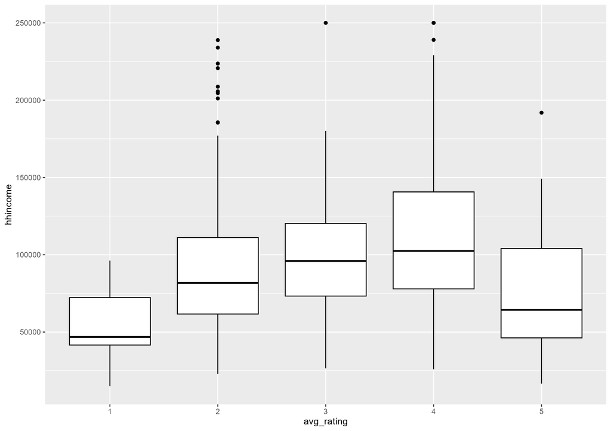

**Plot 2.**

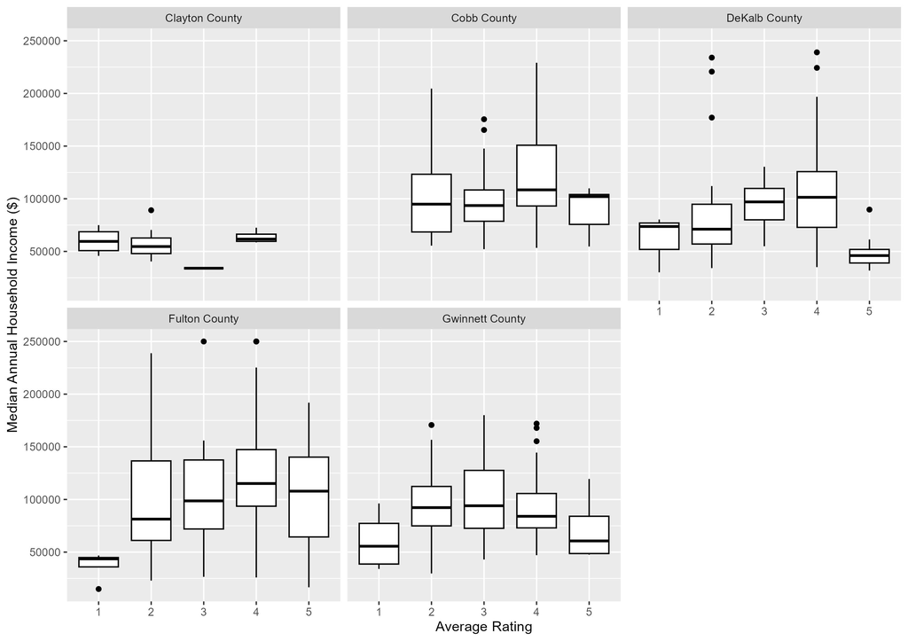

**Plot 3.**

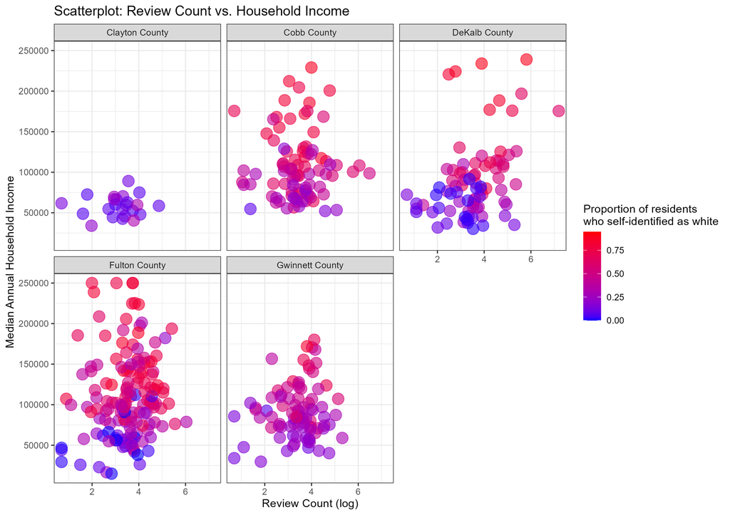

**Plot 4.**

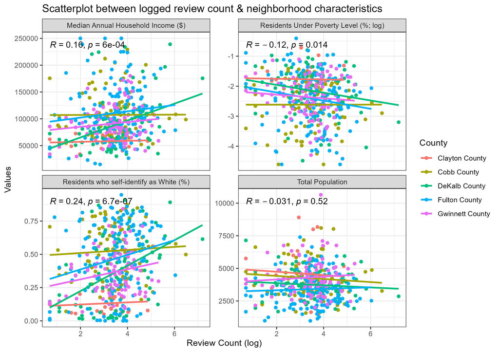

**Hint**: I used pivot_longer() to create Plot 4.

# Working with R Markdown

- You may copy and paste the instructions above into your script.
- Keep your document readable, well-formatted, and concise:
  - Avoid making the document unnecessarily lengthy by printing or plotting everything.
  - **ADD COMMENTS before and/or inside each code chunk** (using `#`) to explain what your code is doing.
- Remember that every time you click **Knit**, the entire script runs.

# Submission Guidelines

- Write your report and R code in an R Markdown (`.Rmd`) script.
- Use the **Knit** button in RStudio to render the document as HTML.
- Submit **one of the following two** through Canvas. They are graded identically – pick whichever you prefer.
  - **Option A – RPubs link.** Publish the rendered HTML to **RPubs** and submit the URL.
  - **Option B – HTML file.** Submit the rendered `.html` file itself. Choose this if you would rather not publish your work publicly.
- Due **10/16/2026 Friday 11:59 PM**.
- A short quiz on this assignment may follow in the session after it is due. If there is one, the quiz score acts as a multiplier on this assignment’s grade. See [Assignment quizzes](https://ujhwang.github.io/urban-analytics-2026/#assignment-quizzes) in the syllabus.